Run this file on the command line with $ Rscript -e “library(knitr)” -e ‘knit(“data_cleaning.Rmd”)’

```r
library(baseballDBR)
library(Lahman)
library(tidyverse)
library(GGally)
#library(mltools) # For one_hot. But it gives the usual unhelpful crap R error message
```

## Postseason

### Augmenting Postseason with #games and passing that on to BattingPost

```r
SeriesPost <- mutate(Lahman::SeriesPost, GamesInThisRound = wins + losses + ties)
SeriesPost <- select(SeriesPost, yearID, round, GamesInThisRound)
BattingPost <- inner_join(Lahman::BattingPost, SeriesPost, by=c("yearID", "round"))
```

### Compress postseason rounds into one row per player

Players who appeared in multiple postseason rounds in a year have a row for each round. Which isn’t what we want. So we have to sum the counts from the multiple rounds.

```r
#BattingPost <- filter(BattingPost, playerID=="ripkeca01" | playerID=="anderbr01")

selected_postseason <- select(BattingPost, -c(round, teamID, lgID))
grouped_postseason <- group_by(selected_postseason, yearID, playerID)
summarized_postseason <- summarize_all(grouped_postseason, sum)
nrow(summarized_postseason)
```

```
[1] 9956
```

### Removing NA from postseason

Now let’s see how prevalent NA is in the postseason.

```r
nrow(summarized_postseason %>% na.omit())
```

```
[1] 9755
```

We lose 201 rows if we throw out all the rows with na. But dropping all na’s could leave us with a biased dataset if certain types of players have NAs when others don’t, so instead let’s look at when the na’s stop:

```r
summarise_all(summarized_postseason, funs(mean(is.na(.))))
```

[output not shown]

| yearID | playerID | G | AB | R | H | X2B | X3B | HR | RBI | SB | CS | BB | SO | IBB | HBP | SH | SF | GIDP | GamesInThisRound |
| --- | --- | --- | --- | --- | --- | --- | --- | --- | --- | --- | --- | --- | --- | --- | --- | --- | --- | --- | --- |
| 1884 | 0 | 0 | 0 | 0 | 0 | 0 | 0 | 0 | 0 | 0 | 1 | 0 | 0 | 0 | 1 | 1 | 1 | 1 | 0 |
| 1885 | 0 | 0 | 0 | 0 | 0 | 0 | 0 | 0 | 0 | 0 | 1 | 0 | 0 | 0 | 1 | 1 | 1 | 1 | 0 |
| 1886 | 0 | 0 | 0 | 0 | 0 | 0 | 0 | 0 | 0 | 0 | 1 | 0 | 0 | 0 | 1 | 1 | 1 | 1 | 0 |
| 1887 | 0 | 0 | 0 | 0 | 0 | 0 | 0 | 0 | 0 | 0 | 1 | 0 | 0 | 0 | 1 | 1 | 1 | 1 | 0 |
| 1888 | 0 | 0 | 0 | 0 | 0 | 0 | 0 | 0 | 0 | 0 | 1 | 0 | 0 | 0 | 1 | 1 | 1 | 1 | 0 |
| 1889 | 0 | 0 | 0 | 0 | 0 | 0 | 0 | 0 | 0 | 0 | 1 | 0 | 0 | 0 | 1 | 1 | 1 | 1 | 0 |
| 1890 | 0 | 0 | 0 | 0 | 0 | 0 | 0 | 0 | 0 | 0 | 1 | 0 | 0 | 0 | 1 | 1 | 1 | 1 | 0 |
| 1892 | 0 | 0 | 0 | 0 | 0 | 0 | 0 | 0 | 0 | 0 | 1 | 0 | 0 | 0 | 1 | 1 | 1 | 1 | 0 |
| 1903 | 0 | 0 | 0 | 0 | 0 | 0 | 0 | 0 | 0 | 0 | 0 | 0 | 0 | 0 | 0 | 0 | 0 | 0 | 0 |
| 1905 | 0 | 0 | 0 | 0 | 0 | 0 | 0 | 0 | 0 | 0 | 0 | 0 | 0 | 0 | 0 | 0 | 0 | 0 | 0 |

[output cut: 112 more lines]

Only 1884 -> 1892 have NAs, which are for CS, HBP, SH, SF, GIDP. 1903 and forward are complete.

```r
postseason_complete_rows <- filter(summarized_postseason, yearID > 1902)
nrow(postseason_complete_rows)
```

```
[1] 9755
```

This is the same number as just dropping all the na’s, from the code chunk named drop_all_nas above, which means there are 0 years when some players have na’s but others don’t.

```r
summarized_postseason_no_na <- na.omit(postseason_complete_rows)
nrow(summarized_postseason_no_na)
```

```
[1] 9755
```

If those two numbers don’t match then the earlier 1903 filtering isn’t good enough.

```r
summarized_postseason_no_na_at_least_1_AB <- filter(summarized_postseason_no_na, AB > 0)
nrow(summarized_postseason_no_na_at_least_1_AB)
```

```
[1] 7037
```

```r
summarized_postseason_no_na$P_OPS <- OPS(summarized_postseason_no_na)
summarized_postseason_no_na <- na.omit(summarized_postseason_no_na)
nrow(summarized_postseason_no_na)
```

```
[1] 7037
```

If those two numbers match then the only reason players have NA after adding OPS is because they had 0 AB.

## Regular season

```r
nrow(Batting)
```

```
[1] 105861
```

### Fixing traded/released players in regular season

How are traded players represented? Willie Mays was traded once midseason.

```r
#mays <- filter(Lahman::Batting, playerID=="mayswi01", yearID > 1970)
#mays
```

The player is only going to play in the postseason for his last team/league (right?), so let’s only keep last stint, throw out the rest.

```r
#group_by(mays, playerID, yearID) %>% filter(stint == max(stint))
```

Ok, that code works for Willie Mays. Now apply it to the whole Batting table and ensure there is only one row per player-year.

```r
Batting <- group_by(Lahman::Batting, playerID, yearID)
nrow(Batting)
```

```
[1] 105861
```

```r
only_last_stint <- Batting %>% filter(stint == max(stint))
Batting_with_rows <- summarize(Batting, rows = n())
nrow(only_last_stint)
```

```
[1] 97992
```

```r
nrow(Batting_with_rows)
```

```
[1] 97992
```

### Removing NA from regular season

```r
last_stint_grouped_by_year <- ungroup(only_last_stint) %>% group_by(yearID)
summarise_all(last_stint_grouped_by_year, funs(sum(is.na(.))))
```

| yearID | playerID | stint | teamID | lgID | G | AB | R | H | X2B | X3B | HR | RBI | SB | CS | BB | SO | IBB | HBP | SH | SF | GIDP |
| --- | --- | --- | --- | --- | --- | --- | --- | --- | --- | --- | --- | --- | --- | --- | --- | --- | --- | --- | --- | --- | --- |
| 1871 | 0 | 0 | 0 | 0 | 0 | 0 | 0 | 0 | 0 | 0 | 0 | 0 | 0 | 0 | 0 | 0 | 115 | 115 | 115 | 115 | 0 |
| 1872 | 0 | 0 | 0 | 0 | 0 | 0 | 0 | 0 | 0 | 0 | 0 | 0 | 0 | 0 | 0 | 0 | 143 | 143 | 143 | 143 | 0 |
| 1873 | 0 | 0 | 0 | 0 | 0 | 0 | 0 | 0 | 0 | 0 | 0 | 0 | 0 | 0 | 0 | 0 | 122 | 122 | 122 | 122 | 0 |
| 1874 | 0 | 0 | 0 | 0 | 0 | 0 | 0 | 0 | 0 | 0 | 0 | 0 | 0 | 0 | 0 | 0 | 120 | 120 | 120 | 120 | 0 |
| 1875 | 0 | 0 | 0 | 0 | 0 | 0 | 0 | 0 | 0 | 0 | 0 | 0 | 0 | 0 | 0 | 0 | 189 | 189 | 189 | 189 | 0 |
| 1876 | 0 | 0 | 0 | 0 | 0 | 0 | 0 | 0 | 0 | 0 | 0 | 0 | 121 | 121 | 0 | 0 | 121 | 121 | 121 | 121 | 121 |
| 1877 | 0 | 0 | 0 | 0 | 0 | 0 | 0 | 0 | 0 | 0 | 0 | 0 | 92 | 92 | 0 | 0 | 92 | 92 | 92 | 92 | 92 |
| 1878 | 0 | 0 | 0 | 0 | 0 | 0 | 0 | 0 | 0 | 0 | 0 | 0 | 77 | 77 | 0 | 0 | 77 | 77 | 77 | 77 | 77 |
| 1879 | 0 | 0 | 0 | 0 | 0 | 0 | 0 | 0 | 0 | 0 | 0 | 0 | 119 | 119 | 0 | 0 | 119 | 119 | 119 | 119 | 119 |
| 1880 | 0 | 0 | 0 | 0 | 0 | 0 | 0 | 0 | 0 | 0 | 0 | 0 | 127 | 127 | 0 | 0 | 127 | 127 | 127 | 127 | 127 |

[output cut: 138 more lines]

So it’s IBB that we don’t have data for most recently. Which is unfortunate. SF and CS probably don’t matter that much, but I suspect IBB is a fairly unique and informative signal. Starting in 1955, we have no NAs.

```r
nrow(inner_join(only_last_stint %>% filter(yearID > 1954), summarized_postseason_no_na, by=c("playerID", "yearID")))
```

```
[1] 5410
```

```r
nrow(inner_join(only_last_stint %>% filter(yearID > 1938), summarized_postseason_no_na, by=c("playerID", "yearID")))
```

```
[1] 5967
```

```r
nrow(inner_join(only_last_stint %>% filter(yearID > 1912), summarized_postseason_no_na, by=c("playerID", "yearID")))
```

```
[1] 6781
```

```r
recent_regular_season <- only_last_stint %>% filter(yearID > 1954)

#recent_regular_season <- select(recent_regular_season, -GIDP, -CS, -IBB, -SF)
```

### Add sabermetric stats to regular season

```r
augmented_recent_regular_season <- recent_regular_season
#augmented_recent_regular_season <- battingStats(data=recent_regular_season)
#is.na(augmented_recent_regular_season)
```

```r
nrow(na.omit(augmented_recent_regular_season))
```

```
[1] 63146
```

```r
augmented_recent_regular_season$Hand_OBP <- OBP(augmented_recent_regular_season)
paste("after OBP", nrow(na.omit(augmented_recent_regular_season)))
```

```
[1] "after OBP 49469"
```

```r
augmented_recent_regular_season$Hand_SLG <- SLG(augmented_recent_regular_season)
paste("after SLG", nrow(na.omit(augmented_recent_regular_season)))
```

```
[1] "after SLG 49330"
```

```r
augmented_recent_regular_season$Hand_BABIP <- BABIP(augmented_recent_regular_season)
paste("after BABIP, which requires H", nrow(na.omit(augmented_recent_regular_season)))
```

```
[1] "after BABIP, which requires H 47463"
```

```r
augmented_recent_regular_season$Hand_ISO <- ISO(augmented_recent_regular_season)
nrow(na.omit(augmented_recent_regular_season))
```

```
[1] 47463
```

```r
augmented_recent_regular_season <- mutate(augmented_recent_regular_season, Hand_SBPerG = SB / G)
nrow(na.omit(augmented_recent_regular_season))
```

```
[1] 47463
```

```r
#augmented_recent_regular_season <- group_by(ungroup(augmented_recent_regular_season), yearID)
#summarise_all(augmented_recent_regular_season, funs(mean(is.na(.))))
augmented_recent_regular_season <- na.omit(augmented_recent_regular_season)
```

presumably because OBP requires PA > 0, and OBP and the rest require AB > 0.

OBP goes from 63146 to 49469. SLG goes from 49469 to 49330.

## Join and finalize

### Join regular and post

```r
aug_bat <- inner_join(augmented_recent_regular_season, summarized_postseason_no_na, by=c("playerID", "yearID"))
aug_bat <- ungroup(ungroup(aug_bat))
fresh_joined_batting <- aug_bat
```

### Drop low-AB players

```r
a <- tibble(rows=0, sd=0)
#for (min_AB in seq(1,10)) {
for (min_AB in 10) {
  AB_filter_joined <- fresh_joined_batting
  nrow(AB_filter_joined)
  sd(AB_filter_joined$P_OPS)
  AB_filter_joined <- filter(AB_filter_joined, AB.x >= min_AB)
  #nrow(AB_filter_joined)
  #sd(AB_filter_joined$P_OPS)
  AB_filter_joined <- filter(AB_filter_joined, AB.y >= min_AB)
  n = nrow(AB_filter_joined)
  s = sd(AB_filter_joined$P_OPS)
  a <- add_row(a,rows=n, sd=s)
}

a <- a[-1,]
#qplot(seq(1,10), a$rows)
#qplot(seq(1,10), a$sd)
```

### First cleanup of joint table

Turn lgID into AL boolean Simplify “stint” into newteam boolean drop most postseason columns.

```r
aug_bat <- AB_filter_joined
aug_bat <- rename(aug_bat, Games=G.x)
aug_bat$AL = ifelse(aug_bat$lgID=="AL",1,0)
aug_bat$SameTeam = ifelse(aug_bat$stint==1, 1, 0)
aug_bat <- select(aug_bat, -ends_with(".y"))
aug_bat <- select(aug_bat, -GamesInThisRound, -lgID, -stint)
```

### Join with some player biographical stats

And do some more cleaning/processing

```r
my_master <- select(Master, playerID, birthYear, weight, height, bats)
raw_final_table <- inner_join(aug_bat, my_master, by=c("playerID"))
```

### One-hot, add Age, drop many columns

```r
cleaned_joint_data <- mutate(raw_final_table, age=yearID-birthYear)
cleaned_joint_data <- mutate(cleaned_joint_data, bats_right = ifelse(bats=='R', 1, 0))
cleaned_joint_data <- mutate(cleaned_joint_data, bats_switch = ifelse(bats=='B', 1, 0))
cleaned_joint_data <- rename_at(cleaned_joint_data, vars(ends_with(".x")), funs(substr(., 1, nchar(.) - 2))) # I hate R
cleaned_joint_data <- select(cleaned_joint_data, -c(playerID, yearID, teamID, birthYear, bats))
```

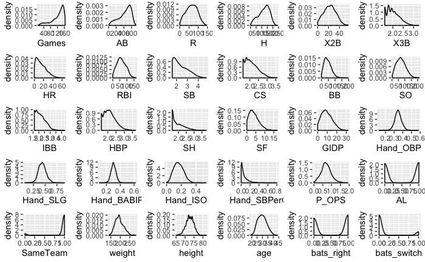

```r
fudge = 5
cleaned_joint_data$HBP = log(fudge + cleaned_joint_data$HBP)
cleaned_joint_data$SB = log(fudge + cleaned_joint_data$SB)
cleaned_joint_data$X3B = log(fudge + cleaned_joint_data$X3B)
cleaned_joint_data$IBB = log(fudge + cleaned_joint_data$IBB)
cleaned_joint_data$CS = log(fudge + cleaned_joint_data$CS)
cleaned_joint_data$SH = log(fudge + cleaned_joint_data$SH)

# https://stackoverflow.com/questions/48507378/plotting-distributions-of-all-columns-in-an-r-data-frame
library(cowplot)
my_plots <- lapply(names(cleaned_joint_data), function(var_x){
  p <-
    ggplot(cleaned_joint_data) +
    aes_string(var_x)

  if(is.numeric(cleaned_joint_data[[var_x]])) {
    p <- p + geom_density()

  } else {
    p <- p + geom_bar()
  }

})
plot_grid(plotlist = my_plots)
```

I’ll do train/test split in python

```r
filename = paste0("all_data_v", packageVersion("Lahman"), "_min_", min_AB,"_AB.csv")
write.csv(cleaned_joint_data, file = filename, row.names=FALSE)
```